# Airbnb: Data Modeling

Tanya Bonilla

11/20/2019

# Predictions

Inititally, I was researching to find out how much people are willing to spend on staying in other people’s homes and the effect it has had on hotels, but due to the fact I could not find data that could answer that question I decided to take another route. I’m predicting that the price of a listing is affected by the amount of bedrooms available.

# Gettting started

We begin by loading in *Airbnb: Tidying the Data* and any library that we plan on using throughout our analysis.

```r
library(rvest)
library(knitr)
library(tidyr)
library(tidyverse)
library(dplyr)
library(caret)
library(jsonlite)
library(ggplot2)

purl("p01_airbnb.Rmd", output = "first_del.r")
source("first_del.r")
```

# Loading and Tidying the Data

We now load in this New York json file we acquired from *Opendatasoft.com* which is a “data sharing platform teams use to access, reuse and share data that grows business.” We utilze the function *fromJSON* from the jsonlite library.

As the data is far too large for a GitHub repository, it is opportune that you download the file with only 19528 records from the site and save it in the same folder that this .Rmd file is in:

https://public.opendatasoft.com/explore/dataset/airbnb-listings/export/?disjunctive.host_verifications&disjunctive.amenities&disjunctive.features&refine.city=New+York

```r
new_york <- fromJSON("airbnb-listings.json")
colnames(new_york)
```

```
## [1] "datasetid"        "recordid"         "fields"
## [4] "geometry"         "record_timestamp"
```

When looking at the file, we see that there are 5 variables:

- **datasetid** - character type with the id of which the data is from
- **recordid** - character type with the recordid of the listing
- **geometry**- dataframe with 2 columns with the listing’s coordinates

```
## [1] "type"        "coordinates"
```

- **fields** - dataframe with 86 variables with details from the listing

```
##  [1] "review_scores_accuracy"         "reviews_per_month"
##  [3] "bathrooms"                      "first_review"
##  [5] "geolocation"                    "cancellation_policy"
##  [7] "accommodates"                   "calendar_last_scraped"
##  [9] "medium_url"                     "host_neighbourhood"
## [11] "street"                         "review_scores_communication"
## [13] "calendar_updated"               "country_code"
## [15] "review_scores_cleanliness"      "property_type"
## [17] "availability_365"               "id"
## [19] "market"                         "features"
## [21] "city"                           "availability_60"
## [23] "picture_url"                    "zipcode"
## [25] "host_location"                  "availability_90"
## [27] "state"                          "thumbnail_url"
## [29] "amenities"                      "host_listings_count"
```

[output cut: 28 more lines]

- **record_timestamp** - character

As we are more interested in the *fields* dataframe within the JSON data, let’s create a tibble that will hold the variables we deem important for modeling.

```r
new_york$fields$bedrooms <- as.factor(new_york$fields$bedrooms)
#new_york$fields$bathrooms <- as.factor(new_york$fields$bathrooms)
new_york$fields$zipcode <- as.factor(new_york$fields$zipcode)
new_york$fields$property_type <- as_factor(new_york$fields$property_type)

levels(new_york$fields$bedrooms)
```

```
## [1] "0" "1" "2" "3" "4" "5" "6"
```

```r
levels(new_york$fields$bathrooms)
```

```r
levels(new_york$fields$zipcode)
```

```
##   [1] "10000"      "10001"      "10002"      "10002-2289" "10003"
##   [6] "10003-8623" "10004"      "10005"      "10006"      "10007"
##  [11] "10009"      "10010"      "10011"      "10012"      "10013"
##  [16] "10014"      "10016"      "10017"      "10018"      "10019"
##  [21] "10021"      "10022"      "10023"      "10024"      "10025"
##  [26] "10026"      "10027"      "10028"      "10029"      "10030"
##  [31] "10031"      "10032"      "10033"      "10034"      "10035"
##  [36] "10036"      "10037"      "10038"      "10039"      "10040"
##  [41] "10044"      "10065"      "10069"      "10075"      "10078"
##  [46] "10080"      "10106"      "10111"      "10118"      "10119"
##  [51] "10128"      "10129"      "10162"      "10270"      "10279"
##  [56] "10280"      "10281"      "10282"      "10301"      "10303"
##  [61] "10304"      "10451"      "10452"      "10453"      "10455"
##  [66] "10456"      "10463"      "10465"      "10471"      "11101"
##  [71] "11102"      "11103"      "11103-3233" "11104"      "11105"
##  [76] "11106"      "11109"      "11201"      "11205"      "11206"
##  [81] "11207"      "11208"      "11209"      "11211"      "11212"
##  [86] "11213"      "11214"      "11215"      "11216"      "11217"
##  [91] "11218"      "11219"      "11220"      "11221"      "11222"
##  [96] "11223"      "11225"      "11226"      "11230"      "11231"
## [101] "11232"      "11233"      "11237"      "11238"      "11249"
## [106] "11354"      "11365"      "11368"      "11372"      "11373"
## [111] "11374"      "11375"      "11377"      "11378"      "11385"
## [116] "11416"      "11432"      "11691"      "1m"
```

```r
levels(new_york$fields$property_type)
```

```
##  [1] "Apartment"          "Loft"               "Other"
##  [4] "House"              "Condominium"        "Villa"
##  [7] "Townhouse"          "Serviced apartment" "Timeshare"
## [10] "Bed & Breakfast"    "Castle"             "Bungalow"
## [13] "Hostel"             "Guesthouse"         "Boutique hotel"
## [16] "Lighthouse"         "Dorm"               "Vacation home"
## [19] "Cabin"              "Hut"                "Boat"
## [22] "Guest suite"
```

```r
new_york_fields <- tibble (
  price = new_york$fields$price,
  bathrooms = new_york$fields$bathrooms,
  bedrooms = new_york$fields$bedrooms,
  property_type = new_york$fields$property_type,
  zipcode = new_york$fields$zipcode,
  availability_365  = new_york$fields$availability_365,
  host_location = new_york$fields$host_location,
  host_listings_count = new_york$fields$host_listings_count,
  neighbourhood_group_cleansed = new_york$fields$neighbourhood_group_cleansed,
  host_neighbourhood = new_york$fields$host_neighbourhood,
  host_id = new_york$fields$host_id,
  neighbourhood = new_york$fields$neighbourhood,
  geolocation = new_york$fields$geolocation,
  bed_type = new_york$fields$bed_type,
  calendar_last_scraped = new_york$fields$calendar_last_scraped,
  record_timestamp = new_york$record_timestamp
)

listing_location <- tibble (
    zipcode = new_york$fields$zipcode,
    neighbourhood_group_cleansed = new_york$fields$neighbourhood_group_cleansed,
    listings_street = new_york$fields$street,
    neighbourhood = new_york$fields$neighbourhood,
    geolocation = new_york$fields$geolocation
)

host <- tibble(
    host_location = new_york$fields$host_location,
    host_neighbourhood = new_york$fields$host_neighbourhood,
    host_listings_count = new_york$fields$host_listings_count,
)
new_york_fields <- new_york_fields %>% drop_na()
new_york_fields
```

```
## # A tibble: 15,954 x 16
##    price bathrooms bedrooms property_type zipcode availability_365
##    <int>     <dbl> <fct>    <fct>         <fct>              <int>
##  1   115         1 1        Apartment     10021                 92
##  2   290         0 1        Apartment     10002                  0
##  3    60         1 1        Apartment     10002                133
##  4    99         1 1        Loft          10002                167
##  5   110         1 1        Apartment     10002                 66
##  6   351         1 0        Loft          10002                  0
##  7   190         1 1        Apartment     10002                125
##  8   149         1 0        Apartment     10002                 47
##  9   200         1 1        Apartment     10009                178
## 10   200         1 1        Apartment     10002                361
## # … with 15,944 more rows, and 10 more variables: host_location <chr>,
## #   host_listings_count <int>, neighbourhood_group_cleansed <chr>,
## #   host_neighbourhood <chr>, host_id <chr>, neighbourhood <chr>,
## #   geolocation <list>, bed_type <chr>, calendar_last_scraped <chr>,
## #   record_timestamp <chr>
```

# Modeling

Now that we have our new dataframe, we can focus on modeling the data. The plan is to find if there is any sort of relationship between the listing’s price and its available bedrooms and bathrooms as we are looking to see if there is any relationship between the two.

```r
set.seed(385)
sample_selection <- createDataPartition(new_york_fields$price, p = 0.70, list = FALSE)
train <- new_york_fields[sample_selection,]
test <- new_york_fields[-sample_selection,]
train_model <- lm(price ~ bedrooms + bathrooms, data = train)
predictions <- train_model %>% predict(test)
```

Now that we made the model, we can look at the R<sup>2</sup> which is a “…statistical measure of how close the data are to the fitted regression line” and mean absolute error (MAE) which is a “measure of difference between two continuous variables.” The bigger R<sup>2</sup> is the better and the smaller MAE the better.

```r
summary(train_model)
```

```
##
## Call:
## lm(formula = price ~ bedrooms + bathrooms, data = train)
##
## Residuals:
##     Min      1Q  Median      3Q     Max
## -583.51  -57.64  -18.52   42.36  866.36
##
## Coefficients:
##             Estimate Std. Error t value Pr(>|t|)
## (Intercept)   93.782      4.204  22.309  < 2e-16 ***
## bedrooms1    -34.878      2.911 -11.983  < 2e-16 ***
## bedrooms2     87.509      3.894  22.473  < 2e-16 ***
## bedrooms3    192.208      6.480  29.663  < 2e-16 ***
## bedrooms4    259.650     13.456  19.297  < 2e-16 ***
## bedrooms5    124.745     34.331   3.634 0.000281 ***
## bedrooms6    303.445     71.785   4.227 2.39e-05 ***
## bathrooms     73.736      3.232  22.811  < 2e-16 ***
## ---
## Signif. codes:  0 '***' 0.001 '**' 0.01 '*' 0.05 '.' 0.1 ' ' 1
##
## Residual standard error: 101.1 on 11161 degrees of freedom
## Multiple R-squared:  0.326,  Adjusted R-squared:  0.3255
## F-statistic: 771.1 on 7 and 11161 DF,  p-value: < 2.2e-16
```

```r
R2(predictions, test$price)
```

```
## [1] 0.3363125
```

```r
MAE(predictions, test$price)
```

```
## [1] 68.14774
```

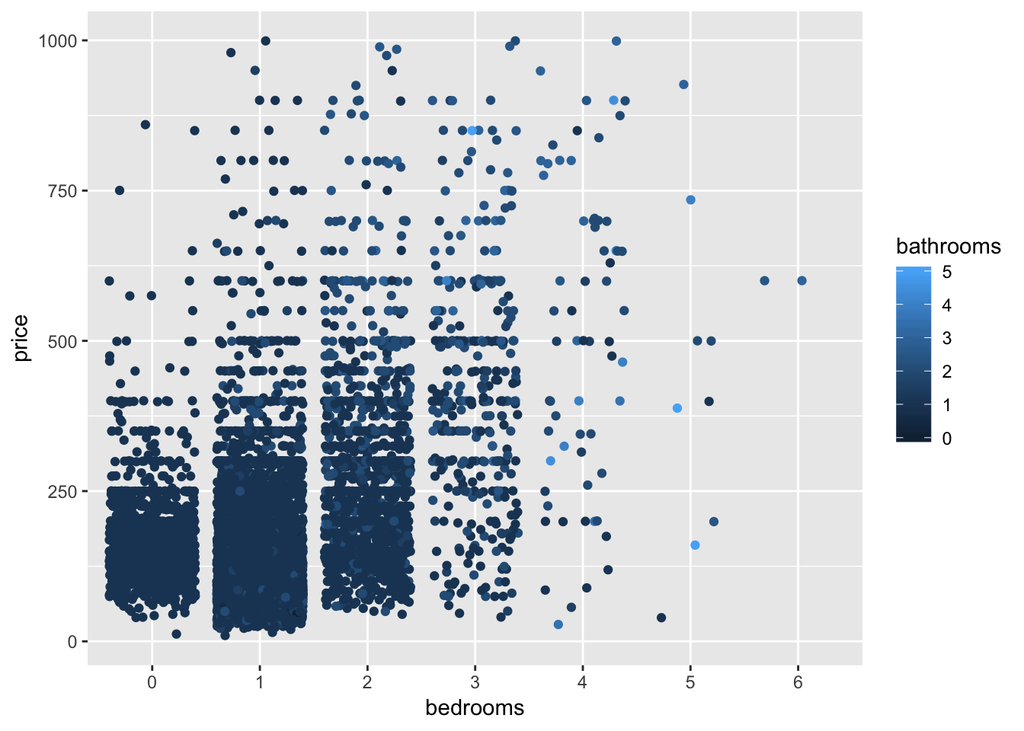

```r
ggplot(train, aes(x = bedrooms, y = price, color = bathrooms)) + geom_jitter() + geom_smooth(method = lm)
```

Looking at the model’s p-value, we can see that that there is some type of relationship between price nad bedrooms as it is < 2.2e-16.

## What now…

After creating a model and analyzing what came of it, we go on to the operationalization and seeing if we can come up with anymore predictions. Refer to: https://tanyabonilla.github.io/p03/